# PAS Ultimate

### Závislosti proměnných

```r
#tapply odělá funkci z posledního parametru pro všechny věci z ostatních parametrů
print("area")
```

```
[1] "area"
```

```r
tapply(prom1,pizza$area,summary)
```

```
$Brent
   Min. 1st Qu.  Median    Mean 3rd Qu.    Max.
  8.792  29.980  43.164  45.196  57.105 123.390

$Camden
   Min. 1st Qu.  Median    Mean 3rd Qu.    Max.
  8.792  33.675  46.764  48.837  64.755 101.799

$Westminster
   Min. 1st Qu.  Median    Mean 3rd Qu.    Max.
  10.99   38.97   49.97   53.06   69.51  134.33
```

```r
print("_____________________________________________")
```

```
[1] "_____________________________________________"
```

```r
print("quality")
```

```
[1] "quality"
```

```r
tapply(prom1,pizza$quality,summary)
```

```
$low
   Min. 1st Qu.  Median    Mean 3rd Qu.    Max.
  10.99   38.22   46.97   50.47   65.66  113.59

$medium
   Min. 1st Qu.  Median    Mean 3rd Qu.    Max.
  10.99   30.28   48.56   50.73   65.83  134.33

$high
   Min. 1st Qu.  Median    Mean 3rd Qu.    Max.
  8.792  30.829  44.970  46.816  59.355 124.434
```

```r
print("_____________________________________________")
```

```
[1] "_____________________________________________"
```

```r
print("rabat")
```

```
[1] "rabat"
```

```r
tapply(prom1,pizza$rabate,summary)#Jde vidět že ten rabat dělá největší rozdíl (median a průměr např.)
```

```
$`FALSE`
   Min. 1st Qu.  Median    Mean 3rd Qu.    Max.
  10.99   26.98   36.97   37.03   43.97   90.21

$`TRUE`
   Min. 1st Qu.  Median    Mean 3rd Qu.    Max.
  8.792  48.564  58.366  60.525  72.935 134.334
```

```r
print("_____________________________________________")
```

```
[1] "_____________________________________________"
```

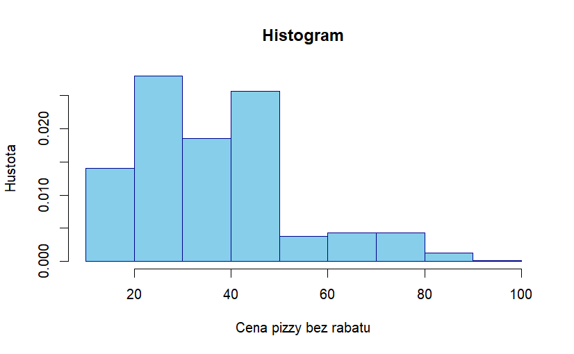

```r
# podivame se na data zvlast podle teto promenne
prom1.T<-pizza$price[pizza$rabate==T]
prom1.F<-pizza$price[pizza$rabate==F]

hist(prom1.F,col="skyblue",border="darkblue",freq=F,main="Histogram",xlab="Cena pizzy bez rabatu",ylab="Hustota")
```

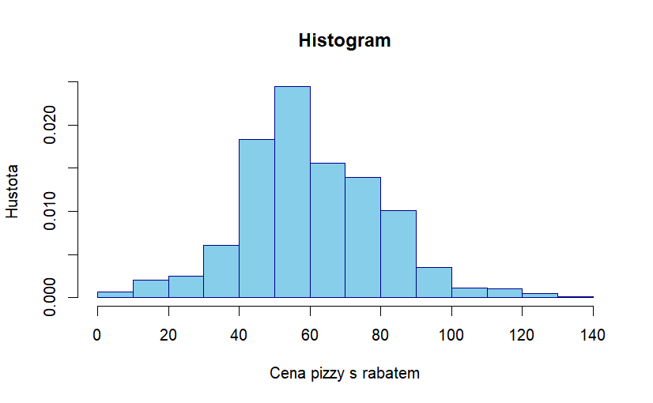

```r
hist(prom1.T,col="skyblue",border="darkblue",freq=F,main="Histogram",xlab="Cena pizzy s rabatem",ylab="Hustota")
```

```r
# je videt, ze ceny se podle rabatu lisi
```

### Useknutý průměr

```r
# predpokladejme, ze chceme urcit "stredni hodnotu dat"
#   s prihlednutim k faktu, ze hodnoty nad 100 uz jsou prilis vysoke
mean(prom1)
```

```
[1] 48.7289
```

```r
median(prom1)
```

```
[1] 46.764
```

```r
# useknuty prumer - kolik procent hodnot je vetsich nez 100?
sum(prom1>100)/length(prom1) #odpověď: 1.42%
```

```
[1] 0.01420217
```

```r
mean(prom1,trim=0.0142)
```

```
[1] 48.35963
```

```r
  # vynechano 1.42% nejvyssich a nejnizsich hodnot
```

### Normalita dat - QQ plot

```r
prom1 = pizza$temperature
```

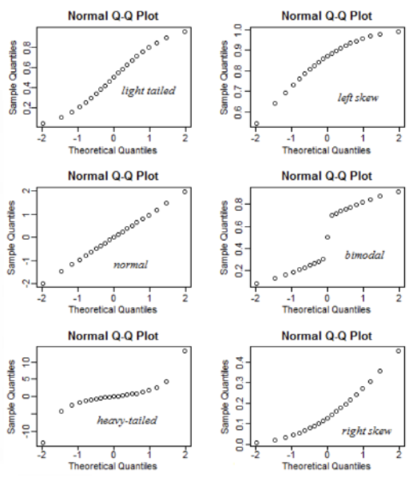

- Přímka QQ-plotu je jak by vypadalo normální rozdělení, s tím porovnávám body

#### Heavy tailed (vysoká špičatost)

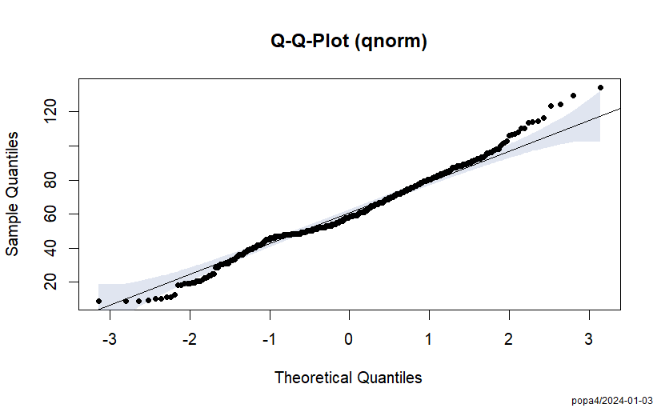

```r
PlotQQ(prom1.T,pch=19,cex=0.8)
```

```r
hist(prom1)
```

[output not shown]

#### Několik vrcholů (modusy)

- V grafu jako “schody”

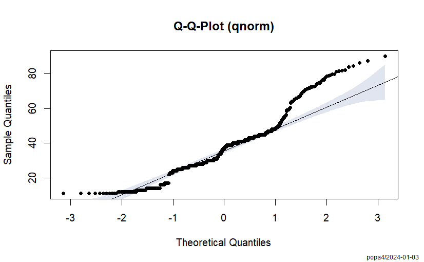

```r
# horni cast dat je prilis vzdalena od "vetsiny"
PlotQQ(prom1.F,pch=19,cex=0.8)
```

```r
hist(prom1)
```

[output not shown]

- Tady jde vidět že je to “prohlé dolů” = ocas vpravo + shody(multimodální)

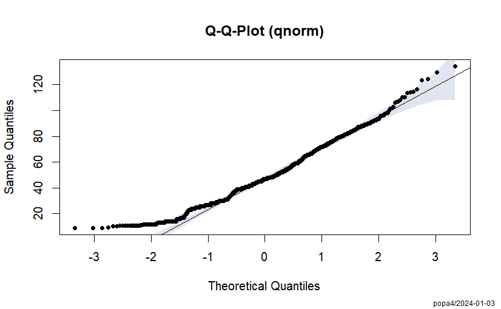

```r
prom1<-pizza$price
PlotQQ(prom1,pch=19,cex=0.8)
```

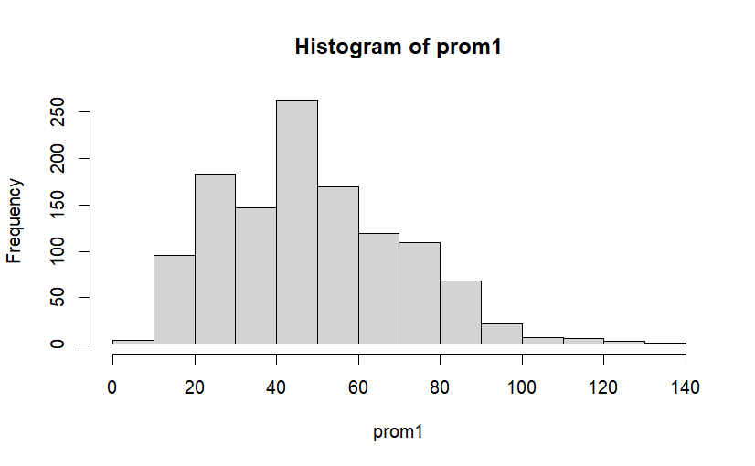

```r
  # v nizkych hodnotach mam malo hodnot, schody odpovidaji "vice vrcholum"
hist(prom1)
```

- Levostranná šikmost (prohlé nahoru)

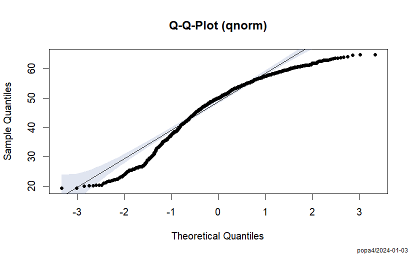

```r
prom1<-pizza$temperature
PlotQQ(prom1,pch=19,cex=0.8)
```

```r
hist(prom1)
```

[output not shown]

- Pravostranná šikmost (prohlé dolů)

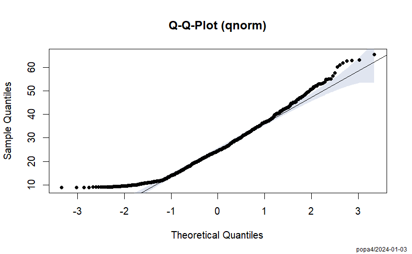

```r
prom1<-pizza$delivery_min
PlotQQ(prom1,pch=19,cex=0.8)
```

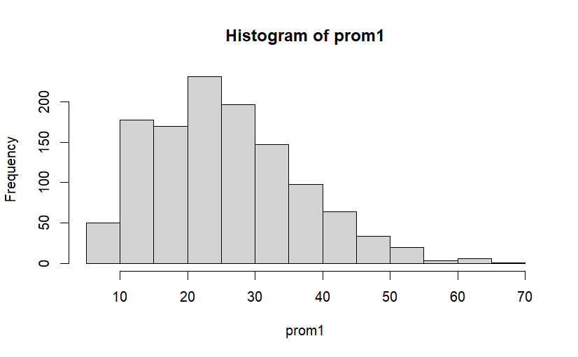

```r
hist(prom1)
```

### Vztah 2 proměnných

- Vztah dvou kategorickych promennych popisujeme kontingencni tabulkou

```r
# Existuje zavislost mezi mistem a kvalitou pizzy?
prom2<-pizza$area
prom3<-pizza$quality
(tab<-table(prom2,prom3))
```

```
             prom3
prom2         low medium high
  Brent        29    131  230
  Camden       45     97  143
  Westminster  79    121  114
```

- Vztah dvou ciselnych promennych popisujeme pomoci bodoveho (rozptyloveho) grafu, korelacniho koeficientu, korelacni tabulky

#### Scatterplot

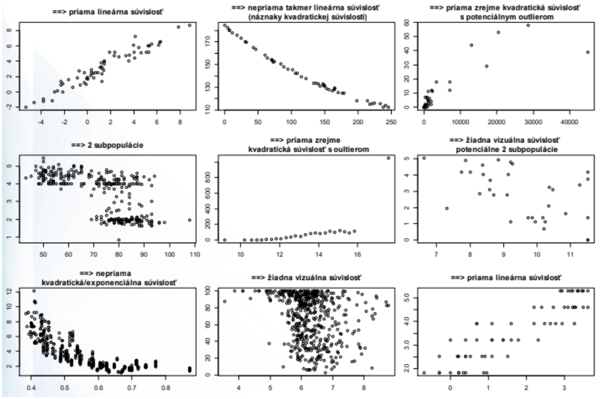

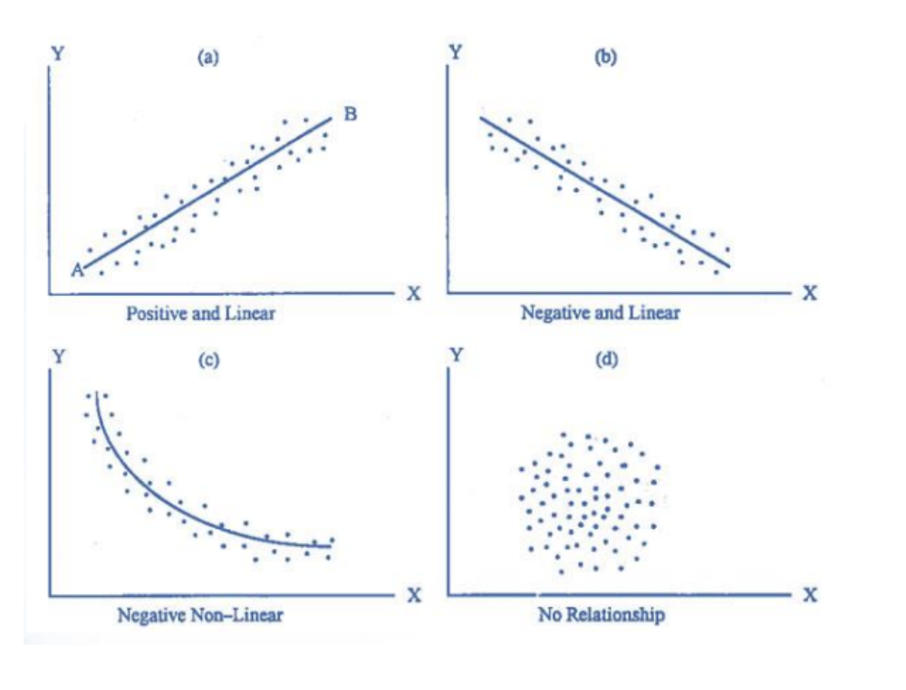

- Tady jde na scatter plotu vidět negativní lineární závislot (můj názor tho)

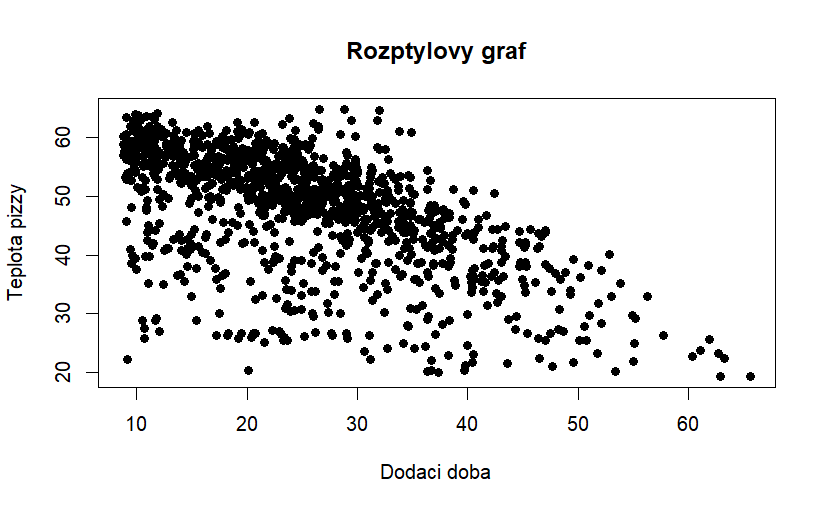

```r
# Jaky je vztah mezi teplotou pizzy a dobou dovazky
prom4<-pizza$temperature
prom5<-pizza$delivery_min
plot(prom4~prom5,pch=19,main="Rozptylovy graf",xlab="Dodaci doba",ylab="Teplota pizzy")
```

#### Kovariance a Korelace

- **Kladná** **kovariance** = **jedna proměnná zvyšuje, druhá také roste**.
- **Negativní** kovariance = **proměnná zvyšuje, druhá klesá**.
- Hodnota korelace se pohybuje od -1 do 1.
- Hodnota 1 znamená perfektní pozitivní lineární vztah, -1 znamená perfektní negativní lineární vztah a hodnota blízká 0 indikuje minimální lineární vztah.

```r
 # kovariance
cov(prom4,prom5,use="complete.obs")
```

```
[1] -61.18979
```

```r
 # korelace
cor(prom4,prom5,use="complete.obs")
```

```
[1] -0.5766054
```

#### Korelační tabulka

- V tomhle případe to je prakticky kontigenční jenže podle PANA DOCENTA když je to mezi dvěmi číselnými proměnými tak je to korelační tabulka (OPRAVDOVÁ korelační tabulka je dle pana docenta korelační MATICE)

```r
prom4.c <- factor(ifelse(prom4<=20, '<20', ifelse(prom4<=30, '20-30',
          ifelse(prom4<=40, '30-40', ifelse(prom4<=50, '40-50',
          ifelse(prom4<=60, '50-60', '>60'))))),
          levels=c("<20","20-30","30-40","40-50","50-60",">60"))
prom5.c <- factor(ifelse(prom5<=10, '<10', ifelse(prom5<=20, '10-20',
          ifelse(prom5<=30, '20-30', ifelse(prom5<=40, '30-40',
          ifelse(prom5<=50, '40-50', ifelse(prom5<=60, '50-50', '>60')))))),
          levels=c("<10","10-20","20-30","30-40","40-50","50-60",">60"))
table(prom4.c,prom5.c)
```

```
       prom5.c
prom4.c <10 10-20 20-30 30-40 40-50 50-60 >60
  <20     0     0     0     1     0     0   2
  20-30   1    12    19    22    15     0   5
  30-40   4    17    37    39    42     0   0
  40-50   3    54   143   118    27     0   0
  50-60  34   219   212    38     2     0   0
  >60     8    44    16     4     0     0   0
```